# TFM - Análisis de Serie Temporal Mensual

Maria del Carmen Martínez Caro

Máster Bioestadística

### Librerías utilizadas

```r
library(readr) # leer datos
library(ggplot2) # graficar
library(forecast)
library(grid)
library(gridExtra)
library(stats) # para convertir a clase serie temporal con ts
library(tidyverse) # para agrupar bien los datos
library(cowplot) # combinación de grágicos FAC
library(urca)
```

# 1. Introducción

Los datos corresponden a registros de llamadas de intentos de suicidio recogidas por el 112 en la Comunidad Valenciana. Se disponde de 35348 observaciones; datos desde el 1 de enero de 2018 hasta el 30 de abril de 2022 (*01/01/18 - 30/04/22*).

Utilizando la librería *tidyverse* se agrupan los datos en función de los meses y con la función *ts* se convierte en una serie temporal mensual con 52 observaciones.

```r
datos_validos <- datos_TFM %>%
    group_by(datos_TFM$fecha_mes) %>% # Se agrupa en función del mes
    summarise(n = n())

serie <- ts(datos_validos$n, start = c(2018, 1), # Enero de 2018
            freq = 12) # 12 meses tiene cada año
```

# 2. Descriptiva

La figura 2.1 muestra la evolución de la serie, la cual muestra una **tendencia** creciente en el número de llamadas a partir de febrero de 2021.

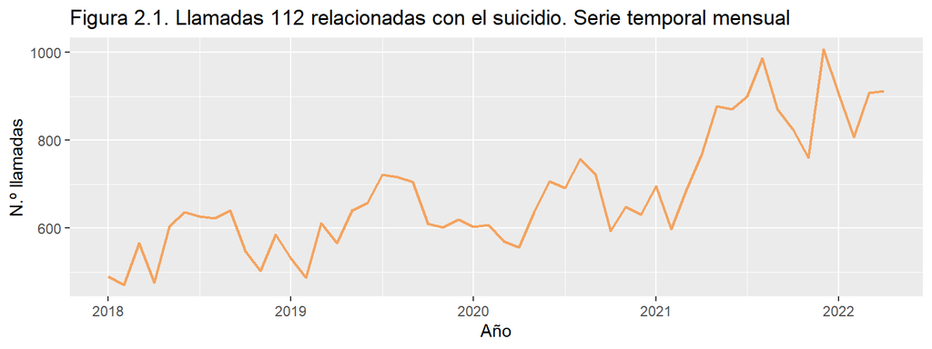

```r
autoplot(serie,
         xlab = "Año",
         ylab = "N.º llamadas",
         main = "Figura 2.1. Llamadas 112 relacionadas con el suicidio. Serie temporal mensual",
         col = "#f4a460", size = 0.8) +
    scale_x_continuous(breaks = seq(2018, 2023, 1))
```

Se comprueba el tipo de esquema para saber la forma en la que se relacionan las componentes de la serie temporal.

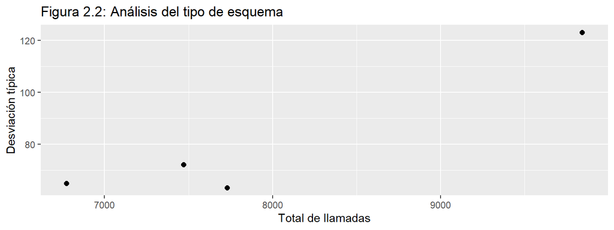

```r
CasosAnual = aggregate(serie, FUN = sum) # número de llamadas por año
DesviacionAnual = aggregate(serie, FUN = sd)

ggplot() +
  geom_point(aes(x = CasosAnual, y = DesviacionAnual), size = 2) +
xlab("Total de llamadas") +
ylab("Desviación típica") +
ggtitle("Figura 2.2: Análisis del tipo de esquema")
```

En el gráfico cada punto representa un año donde la coordenada *X* es el número de llamadas y la coordenada *Y* la desviación típica del número de llamadas para los meses de ese año.

Como sólo se tienen cuatro años (y del último se tienen sólo cuatro meses de datos), no se puede confirmar un patrón muy diferenciable, pero podría decirse que el esquema de la serie tiende a ser un **esquema multiplicativo**; ya que el último año que es el que tiene los meses con mayor número de llamadas se corresponde con una mayor variabilidad intra-anual.

## 2.1. Tendencia

Si se agregan los datos en números de llamadas por año, se pueden identificar mejor los posibles cambios de tendencia.

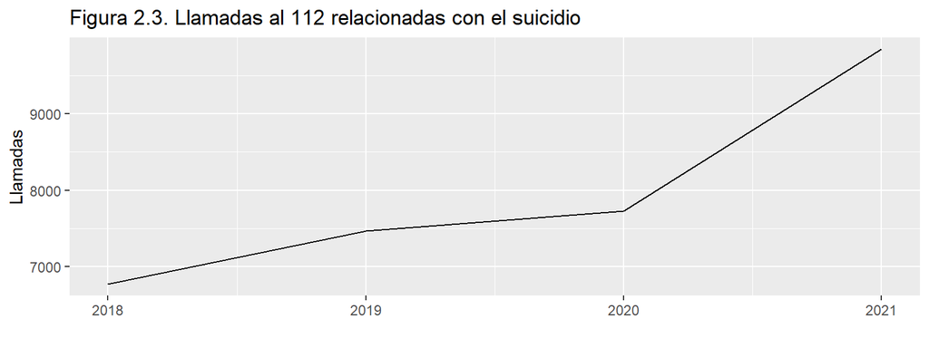

```r
autoplot(aggregate(serie, FUN = sum), # se agrega los datos de cada periodo estacional completo
           # (también se podría mirar con mean en vez de sum)
xlab = "",
ylab = "Llamadas",
main = "Figura 2.3. Llamadas al 112 relacionadas con el suicidio") +
scale_x_continuous(breaks = seq(2018, 2023, 1))
```

## 2.2. Estacionalidad

### **Análisis gráfico de la estacionalidad**

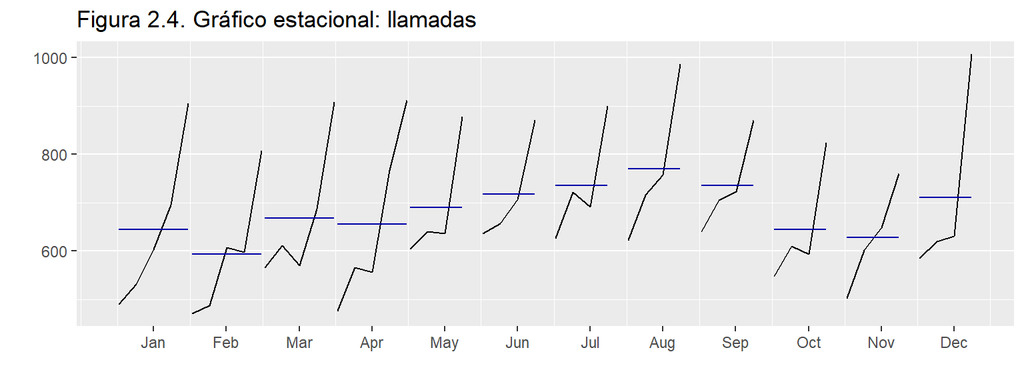

```r
ggsubseriesplot(serie,
                polar = TRUE,
                xlab = "",
                ylab = "",
                main = "Figura 2.4. Gráfico estacional: llamadas") +
                guides(colour = FALSE)
```

### **Análisis numérico de la estacionalidad**

Anteriormente, en la figura 2.2 se ha concluido que la serie presenta un esquema multiplicativo; por tanto, para obtener la componente estacional se han seguido los siguientes comandos:

```r
# Esquema multiplicativo (el seleccionado para interpretar en este caso)
componenteEstacional <- tapply(serie/mean(serie),
                               cycle(serie),
                               FUN = mean)
round(componenteEstacional, 2)
```

```
##    1    2    3    4    5    6    7    8    9   10   11   12
## 0.95 0.87 0.98 0.96 1.02 1.06 1.08 1.13 1.08 0.95 0.92 1.05
```

```r
# Esquema aditivo
componenteEstacional <- tapply(serie - mean(serie),
                               cycle(serie),
                               FUN = mean)
round(componenteEstacional, 2)
```

```
##      1      2      3      4      5      6      7      8      9     10     11
## -34.57 -85.57 -11.17 -23.97  10.48  37.98  55.23  90.98  55.23 -35.77 -51.27
##     12
##  31.23
```

Los valores indican que en los meses de agosto hay un 13% más de llamadas respecto de la media anual, siguiéndole los meses de julio y septiembre con un 8% más. En cambio, los meses de febrero presentan un 13% menos respecto de la media, siguiéndole los meses de noviembre con un 8% menos.

## 2.3. Descomposición de la serie

Después de realizar la descripción de las principales componentes de la serie, la tendencia y la estacionalidad, se va a descomponer la serie. Aunque sea de forma gráfica se busca principalmente analizar el error para tener una idea de la importancia que tendrá la componente de intervención.

Debido a que la serie temporal se ha detectado con esquema multiplicativo se va a utilizar el método de medias móviles para la descomposición.

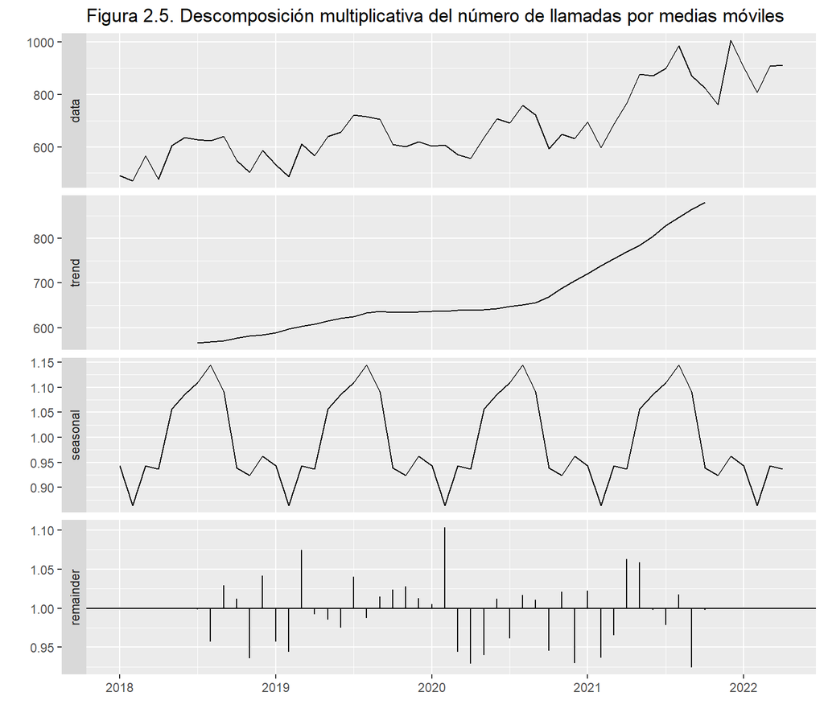

```r
# Descomposición multiplicativa (DesMul)
llamadasDesMul <- decompose(serie, type = "multiplicative")
autoplot(llamadasDesMul,
         xlab = "",
         main = "Figura 2.5. Descomposición multiplicativa del número de llamadas por medias móviles")
```

```r
round(llamadasDesMul$figure, 2)
```

```
##  [1] 0.94 0.86 0.94 0.94 1.06 1.09 1.11 1.14 1.09 0.94 0.92 0.96
```

La **tendencia** obtenida tras la descomposición confirma lo ya observado de que hay una tendencia creciente, más pronunciada al final, en el número de llamadas.

Mirando el **residuo**, en principio, no parece que vayan haber valores atípicos muy significativos.

Respecto de la **componente estacional**, visualmente se observa el aumento de llamadas respecto a la media en verano y la disminución en invierno.

### **Análisis del residuo del método de descomposición**

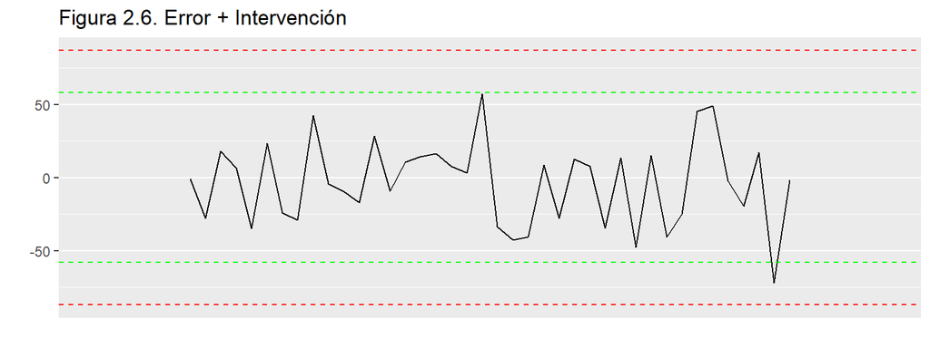

```r
# Restar a la serie original la serie estimada,
# obtenida como producto de la tendencia por la estacionalidad:
# R_t = y_t - (T_t * S_t)
error <- serie - trendcycle(llamadasDesMul) * seasonal(llamadasDesMul)

sderror <-sd(error, na.rm = TRUE)

autoplot(error,
         xlab = "",
         ylab = "",
         main = "Figura 2.6. Error + Intervención",
         colour = "black") +
  geom_hline(yintercept = c(3, 2, -2, -3)*sderror,
             colour = c("red", "green", "green", "red"),
             lty = 2) +
  scale_x_continuous(breaks = seq(1, 226, 10))
```

```r
time(error)[abs(error) > 3*sderror]
```

```
##  [1] NA NA NA NA NA NA NA NA NA NA NA NA
```

```r
time(error)[abs(error) > 2*sderror]
```

```
##  [1]       NA       NA       NA       NA       NA       NA 2021.667       NA
##  [9]       NA       NA       NA       NA       NA
```

```r
# Cómo R guarda el fechado. Siendo una serie mensual.
  # x = mes
  # Enero -> x
  # Febero -> x + 1/12 = x + 0.08333333
  # Marzo -> x + 2/12 = x + 0.16666667
  # Abril -> x + 3/12 = x + 0.25000000
  # Mayo -> x + 4/12 = x + 0.33333333
  # Junio -> x + 5/12 = x + 0.41666667
  # Julio -> x + 6/12 = x + 0.50000000
  # Agosto -> x + 7/12 = x + 0.58333333
  # Septiembre -> x + 8/12 = x + 0.66666667
  # Octubre -> x + 9/12 = x + 0.75000000
  # Noviembre -> x + 10/12 = x + 0.83333333
  # Diciembre -> x + 11/12 = x + 0.91666667
```

La figura 2.6 muestra el error de la descomposición y los intervalos de confianza (IC) al 95% en verde y al 99.7% en rojo.

Se observa que no hay ningún valor extremo que cruce el IC(99.7%), solamente se aprecia un error cruzando el IC(95%) por la parte inferior de la gráfica que corresponde a septiembre de 2021.

# 3. Alisado exponencial

Se ajusta el mejor modelo de alisado para estimar los criterios de calidad para el ajuste y la predicción extra-muestral según el horizonte temporal.

# 3.1. Análisis de la serie

### **Estimación e interpretación**

Aplicando la metodología de alisado exponencial a la serie, si se estima el modelo sin ninguna restricción la función *ets* indica como modelo óptimo ETS(M,A,M). El modelo estimado tiene error multiplicativo, tendencia aditiva y estacionalidad multiplicativa:

$$y_{t+1} = (l_t + b_t) \cdot s_{t+1-m}
\cdot (1+\varepsilon_{t+1})$$

siendo *t* el periodo; *l* el nivel; *s* la estacionalidad; *m* el orden estacional

```r
serieETS <- ets(serie)
summary(serieETS)
```

```
## ETS(M,A,M)
##
## Call:
##  ets(y = serie)
##
##   Smoothing parameters:
##     alpha = 0.1921
##     beta  = 0.1586
##     gamma = 1e-04
##
##   Initial states:
##     l = 530.692
##     b = 5.9742
##     s = 0.9965 0.898 0.937 1.0961 1.14 1.104
##            1.0986 1.0423 0.9301 0.9574 0.8581 0.9417
##
##   sigma:  0.0732
##
##      AIC     AICc      BIC
## 624.5502 642.5502 657.7213
##
## Training set error measures:
##                    ME     RMSE      MAE         MPE     MAPE      MASE
## Training set 1.259001 42.85387 32.97447 -0.01173279 4.776765 0.3232791
##                    ACF1
## Training set 0.02107138
```

Según el método utilizado, los valores óptimos para los parámetros son $\alpha = 0.19$, $\beta = 0.16$, $\gamma = 1*10^{-4}$, $l_0 = 530.69$

El valor de $\gamma = 1*10^{-4}$ indica que la estacionalidad modifica su valor muy lentamente; es decir hay estacionalidad permanece constante en el tiempo.

El valor de arranque óptimo es $l_0 = 530.69$.

Los últimos valores estimados del nivel y la estacionalidad, permiten ver gráficamente la componente estacional: Debido a que el último periodo de la serie temporal mensual corresponde a abril de 2022, los valores de la variable “componenteEstacional” representan las estimaciones de las componentes estacionales correspondientes a los meses posteriores a abril de 2022.

```r
round(serieETS$states, 2)
```

```
##               l      b   s1   s2   s3   s4   s5   s6   s7   s8   s9  s10  s11
## Dec 2017 530.69   5.97 1.00 0.90 0.94 1.10 1.14 1.10 1.10 1.04 0.93 0.96 0.86
## Jan 2018 533.53   3.38 0.94 1.00 0.90 0.94 1.10 1.14 1.10 1.10 1.04 0.93 0.96
## Feb 2018 539.21   5.28 0.86 0.94 1.00 0.90 0.94 1.10 1.14 1.10 1.10 1.04 0.93
## Mar 2018 553.46  12.69 0.96 0.86 0.94 1.00 0.90 0.94 1.10 1.14 1.10 1.10 1.04
## Apr 2018 555.91   4.23 0.93 0.96 0.86 0.94 1.00 0.90 0.94 1.10 1.14 1.10 1.10
## May 2018 564.03   7.45 1.04 0.93 0.96 0.86 0.94 1.00 0.90 0.94 1.10 1.14 1.10
## Jun 2018 572.91   8.62 1.10 1.04 0.93 0.96 0.86 0.94 1.00 0.90 0.94 1.10 1.14
## Jul 2018 578.92   6.47 1.10 1.10 1.04 0.93 0.96 0.86 0.94 1.00 0.90 0.94 1.10
## Aug 2018 577.91   0.30 1.14 1.10 1.10 1.04 0.93 0.96 0.86 0.94 1.00 0.90 0.94
## Sep 2018 579.47   1.34 1.10 1.14 1.10 1.10 1.04 0.93 0.96 0.86 0.94 1.00 0.90
## Oct 2018 581.58   1.97 0.94 1.10 1.14 1.10 1.10 1.04 0.93 0.96 0.86 0.94 1.00
## Nov 2018 579.05  -1.74 0.90 0.94 1.10 1.14 1.10 1.10 1.04 0.93 0.96 0.86 0.94
## Dec 2018 579.38  -0.03 1.00 0.90 0.94 1.10 1.14 1.10 1.10 1.04 0.93 0.96 0.86
## Jan 2019 576.58  -2.32 0.94 1.00 0.90 0.94 1.10 1.14 1.10 1.10 1.04 0.93 0.96
## Feb 2019 572.96  -3.39 0.86 0.94 1.00 0.90 0.94 1.10 1.14 1.10 1.10 1.04 0.93
## Mar 2019 582.96   7.66 0.96 0.86 0.94 1.00 0.90 0.94 1.10 1.14 1.10 1.10 1.04
## Apr 2019 594.06  10.50 0.93 0.96 0.86 0.94 1.00 0.90 0.94 1.10 1.14 1.10 1.10
## May 2019 606.56  12.15 1.04 0.93 0.96 0.86 0.94 1.00 0.90 0.94 1.10 1.14 1.10
## Jun 2019 614.73   8.87 1.10 1.04 0.93 0.96 0.86 0.94 1.00 0.90 0.94 1.10 1.14
## Jul 2019 629.44  13.69 1.10 1.10 1.04 0.93 0.96 0.86 0.94 1.00 0.90 0.94 1.10
## Aug 2019 640.24  11.30 1.14 1.10 1.10 1.04 0.93 0.96 0.86 0.94 1.00 0.90 0.94
## Sep 2019 649.93   9.97 1.10 1.14 1.10 1.10 1.04 0.93 0.96 0.86 0.94 1.00 0.90
## Oct 2019 658.19   8.56 0.94 1.10 1.14 1.10 1.10 1.04 0.93 0.96 0.86 0.94 1.00
## Nov 2019 667.44   9.13 0.90 0.94 1.10 1.14 1.10 1.10 1.04 0.93 0.96 0.86 0.94
## Dec 2019 666.13   0.51 1.00 0.90 0.94 1.10 1.14 1.10 1.10 1.04 0.93 0.96 0.86
## Jan 2020 661.78  -3.50 0.94 1.00 0.90 0.94 1.10 1.14 1.10 1.10 1.04 0.93 0.96
## Feb 2020 667.94   4.47 0.86 0.94 1.00 0.90 0.94 1.10 1.14 1.10 1.10 1.04 0.93
## Mar 2020 657.61  -7.75 0.96 0.86 0.94 1.00 0.90 0.94 1.10 1.14 1.10 1.10 1.04
## Apr 2020 640.05 -15.85 0.93 0.96 0.86 0.94 1.00 0.90 0.94 1.10 1.14 1.10 1.10
## May 2020 621.69 -17.92 1.04 0.93 0.96 0.86 0.94 1.00 0.90 0.94 1.10 1.14 1.10
## Jun 2020 611.41 -11.62 1.10 1.04 0.93 0.96 0.86 0.94 1.00 0.90 0.94 1.10 1.14
## Jul 2020 604.81  -7.47 1.10 1.10 1.04 0.93 0.96 0.86 0.94 1.00 0.90 0.94 1.10
## Aug 2020 610.32   3.25 1.14 1.10 1.10 1.04 0.93 0.96 0.86 0.94 1.00 0.90 0.94
## Sep 2020 622.41  10.55 1.10 1.14 1.10 1.10 1.04 0.93 0.96 0.86 0.94 1.00 0.90
## Oct 2020 633.14  10.70 0.94 1.10 1.14 1.10 1.10 1.04 0.93 0.96 0.86 0.94 1.00
## Nov 2020 658.99  23.21 0.90 0.94 1.10 1.14 1.10 1.10 1.04 0.93 0.96 0.86 0.94
## Dec 2020 672.80  15.44 1.00 0.90 0.94 1.10 1.14 1.10 1.10 1.04 0.93 0.96 0.86
## Jan 2021 697.81  23.34 0.94 1.00 0.90 0.94 1.10 1.14 1.10 1.10 1.04 0.93 0.96
## Feb 2021 716.48  19.49 0.86 0.94 1.00 0.90 0.94 1.10 1.14 1.10 1.10 1.04 0.93
```

[output cut: 53 more lines]

```
## Feb 2021 0.96
## Mar 2021 0.93
## Apr 2021 1.04
## May 2021 1.10
## Jun 2021 1.10
## Jul 2021 1.14
## Aug 2021 1.10
## Sep 2021 0.94
## Oct 2021 0.90
## Nov 2021 1.00
## Dec 2021 0.94
## Jan 2022 0.86
## Feb 2022 0.96
## Mar 2022 0.93
## Apr 2022 1.04
```

```r
# Cada estado del modelo ETS se calcula y actualiza en función de las observaciones pasadas y las estimaciones anteriores.
TT <- nrow(serieETS$states)
serieETS$states[TT,]
```

```
##           l           b          s1          s2          s3          s4
## 989.4911405  17.5366419   0.9301274   0.9574036   0.8581286   0.9416957
##          s5          s6          s7          s8          s9         s10
##   0.9964539   0.8980377   0.9370321   1.0961357   1.1400323   1.1039782
##         s11         s12
##   1.0986484   1.0423443
```

```r
componenteEstacional <- serieETS$states[TT, 14:3]
# (El 14 corresponde a la l, la b y las 12 s)
componenteEstacional
```

```
##       s12       s11       s10        s9        s8        s7        s6        s5
## 1.0423443 1.0986484 1.1039782 1.1400323 1.0961357 0.9370321 0.8980377 0.9964539
##        s4        s3        s2        s1
## 0.9416957 0.8581286 0.9574036 0.9301274
```

```r
# Predicción de un año después:
calculoprediccion <- serieETS$states[TT, 1] + (1:12) * serieETS$states[TT, 2] + serieETS$states[TT, 14:3]
calculoprediccion
```

```
##      s12      s11      s10       s9       s8       s7       s6       s5
## 1008.070 1025.663 1043.205 1060.778 1078.270 1095.648 1113.146 1130.781
##       s4       s3       s2       s1
## 1148.263 1165.716 1183.352 1200.861
```

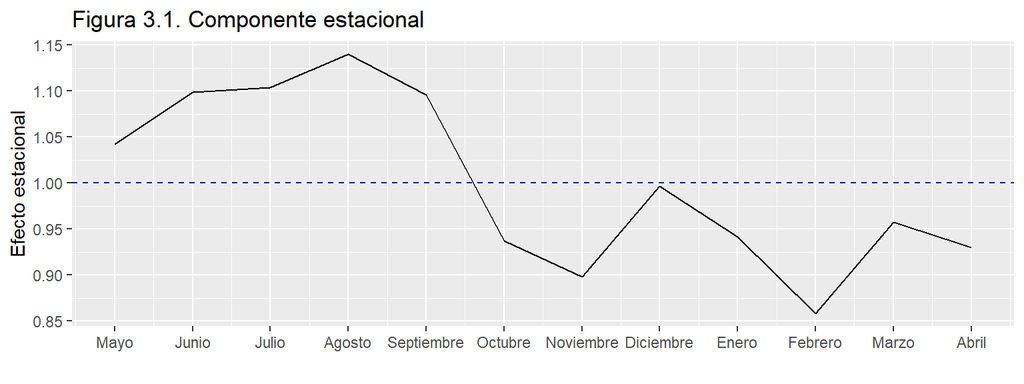

```r
ggplot() +
  geom_line(aes(x = 1:12, y = componenteEstacional)) +
  geom_hline(yintercept = 1, colour = "blue", lty = 2) +
  ggtitle("Figura 3.1. Componente estacional") +
  xlab("") +
  ylab("Efecto estacional") +
  scale_x_continuous(breaks = 1:12,
                     labels = c("Mayo", "Junio", "Julio", "Agosto", "Septiembre", "Octubre", "Noviembre", "Diciembre", "Enero", "Febrero", "Marzo", "Abril"))
```

### **Predicción Alisado**

```r
serieETS.prediccion <- forecast(serieETS, h = 8, level = 95) # 8 meses vista
serieETS.prediccion
```

```
##          Point Forecast    Lo 95    Hi 95
## May 2022      1049.6696 899.1087 1200.231
## Jun 2022      1125.6360 954.8034 1296.469
## Jul 2022      1150.4568 957.7823 1343.131
## Aug 2022      1208.0212 977.5458 1438.497
## Sep 2022      1180.7293 919.9137 1441.545
## Oct 2022      1025.7794 762.5021 1289.057
## Nov 2022       998.8404 702.1466 1295.534
## Dec 2022      1125.7779 741.6781 1509.878
```

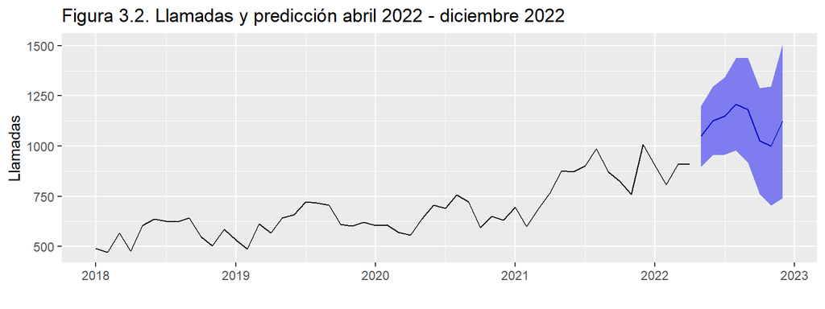

```r
autoplot(serieETS.prediccion,
         xlab = "",
         ylab = "Llamadas",
         main = "Figura 3.2. Llamadas y predicción abril 2022 - diciembre 2022")
```

### **Análisis del error**

Se va a analizar el residuo del modelo, estimado aditivamente.

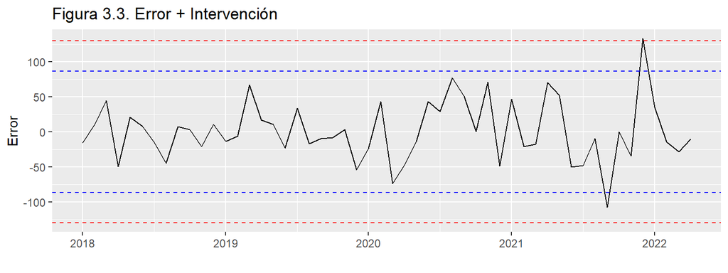

```r
error <- residuals(serieETS, type = "response")
sderror <- sd(error)

autoplot(error,
         xlab = "",
         ylab = "Error",
         main = "Figura 3.3. Error + Intervención",
         colour = "black") +
  geom_hline(yintercept = c(-3, -2, 2, 3)*sderror,
             colour = c("red", "blue", "blue", "red"), lty = 2) +
  scale_x_continuous(breaks = seq(2018, 2023, 1))
```

```r
# Número de semanas con datos anómalos:
sum(abs(error) > 3 * sderror)
```

```
## [1] 1
```

```r
sum(abs(error) > 2.5 * sderror)
```

```
## [1] 1
```

```r
time(error)[abs(error) > 3*sderror]
```

```
## [1] 2021.917
```

```r
time(error)[abs(error) > 2*sderror]
```

```
## [1] 2021.667 2021.917
```

Se aprecia un valor extremo, al final de los datos, en el que el residuo supera las tres desviaciones típicas (diciembre 2021) porque el número de llamadas fue muy superior al estimado por el modelo. Además hay otro residuo que supera las 2 desviaciones típicas (septiembre 2021) que podría llegar a considerarse susceptible de intervención.

# 3.2. Otras alternativas de análisis

Si se tienen en cuenta métodos alternativos como la transformación logarítmica y la insesgada:

| **Id** | **Transformación** | **Modelo** | **Método estimación** |
| --- | --- | --- | --- |
| 1 | Ninguna | MAM | Máxima verosimilitud |
| 2 | Ninguna | MAM | mínimo error en previsiones a 2 periodos vista |
| 3 | Logaritmo | AAA | Máxima verosimilitud |
| 4 | Logaritmo | AAA | mínimo error en previsiones a 2 periodos vista |

**RECORDATORIO**

Al seleccionar el tamaño de k (entrenamiento):

- Si k es demasiado pequeño, el modelo no tiene suficiente información para ajustar adecuadamente y capturar bien la estructura.
- Si k es demasiado grande, se podría incluir ruido o información irrelevante, afectando negativamente la precisión de las predicciones.

Elección de h (datos de prueba):

- Tiene que ser representativo del futuro que se quiere predecir.
- Es necesario tener suficientes datos de prueba para evaluar adecuadamente el rendimiento y la precisión del modelo.

Los valores de k y h deben de ser múltiplos de la frecuencia de la serie.

```r
ets(serie)$method
```

```
## [1] "ETS(M,A,M)"
```

```r
ets(serie, lambda = 0)$method # Serie transformada (transformación logarítmica)
```

```
## [1] "ETS(A,A,A)"
```

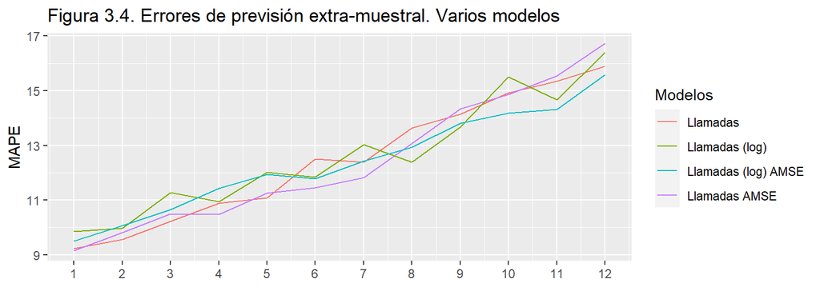

```r
#- Ajuste por alisado usando otros criterios de ajuste
k <- 24 # Podría utilizar 36 meses  en vez de 24 (entrenamiento)
h <- 12  # Pronóstico de 12 meses, o sea un año  (prueba)
TT <- length(serie)
s <- TT - k - h # (periodo de ajuste)

mapeAlisado1 <- matrix(NA, s + 1, h)
mapeAlisado2 <- matrix(NA, s + 1, h)
mapeAlisado3 <- matrix(NA, s + 1, h)
mapeAlisado4 <- matrix(NA, s + 1, h)
mapeAlisado5 <- matrix(NA, s + 1, h)
mapeAlisado6 <- matrix(NA, s + 1, h)

for (i in 0:s) {
  train.set <- subset(serie, start = i + 1, end = i + k)
  test.set <-  subset(serie, start = i + k + 1, end = i + k + h)

  fit <- ets(train.set, model = "MAM", damped = FALSE)
  fcast<-forecast(fit, h = h)
  mapeAlisado1[i + 1,] <- 100*abs(test.set - fcast$mean)/test.set

  fit <- ets(train.set, model = "MAM", damped = FALSE, opt.crit = "amse", nmse = 2)
  fcast<-forecast(fit, h = h)
  mapeAlisado2[i + 1,] <- 100*abs(test.set - fcast$mean)/test.set

  fit <- ets(train.set, model = "AAA", lambda = 0, biasadj = TRUE, damped = FALSE)
  fcast<-forecast(fit, h = h, biasadj = TRUE)
  mapeAlisado3[i + 1,] <- 100*abs(test.set - fcast$mean)/test.set

  fit <- ets(train.set, model = "AAA", lambda = 0, biasadj = TRUE, damped = FALSE,  opt.crit = "amse", nmse = 2)
  fcast<-forecast(fit, h = h, biasadj = TRUE)
  mapeAlisado4[i + 1,] <- 100*abs(test.set - fcast$mean)/test.set

}

errorAlisado1 <- colMeans(mapeAlisado1)
errorAlisado2 <- colMeans(mapeAlisado2)
errorAlisado3 <- colMeans(mapeAlisado3)
errorAlisado4 <- colMeans(mapeAlisado4)

ggplot() +
  geom_line(aes(x = 1:12, y = errorAlisado1, colour = "Llamadas")) +
  geom_line(aes(x = 1:12, y = errorAlisado2, colour = "Llamadas AMSE")) +
  geom_line(aes(x = 1:12, y = errorAlisado3, colour = "Llamadas (log)")) +
  geom_line(aes(x = 1:12, y = errorAlisado4, colour = "Llamadas (log) AMSE")) +
  ggtitle("Figura 3.4. Errores de previsión extra-muestral. Varios modelos") +
  xlab("") +
  ylab("MAPE") +
  scale_x_continuous(breaks= 1:12) +
  scale_color_discrete(name = "Modelos")
```

Todos los métodos resultan similares en calidad de las predicciones en el corto, medio y largo plazo.

Aun así, no se observa una opción más ajustada que el resto, ya que todas muestran una calidad similar en las predicciones a corto, medio y largo plazo.

# 4. Modelos ARIMA

## 4.1. Transformación de la serie

Se van a investigar las transformaciones necesarias para lograr que la serie sea estacionaria y ergódica.

### **Transformación logaritmica**

```r
(nl <- BoxCox.lambda(serie))
```

```
## [1] 0.3447503
```

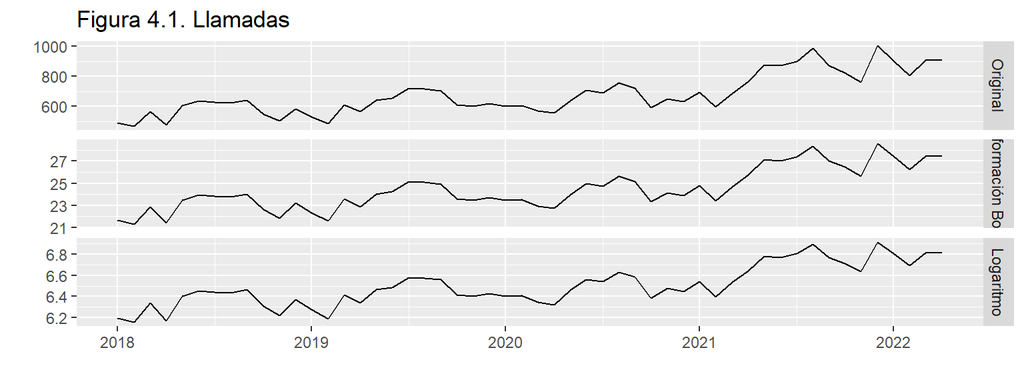

```r
boxserie <-BoxCox(serie, lambda = nl)

series <- cbind("Original" = serie,
                "Transformación Box-Cox" = boxserie,
                "Logaritmo" = log(serie))
autoplot(series,
         facets = TRUE,
         xlab = "",
         ylab = "",
         main = "Figura 4.1. Llamadas")
```

El valor sugerido de
$$\lambda =
0.34$$
es difícil de interpretar; pero la transformación logarítmica (panel inferior) genera una serie muy similar a la transformación de Box-Cox óptica (panel medio). No hay un cambio detectable realmente por tanto se considera que no es necesario utilizar el logaritmo de la serie.

### **Diferenciaciones**

A continuación se usará la función de autocorrelación o correlograma (FAC) para determinar las diferenciaciones necesarias para alcanzar una serie estacionaria en media y ergódica.

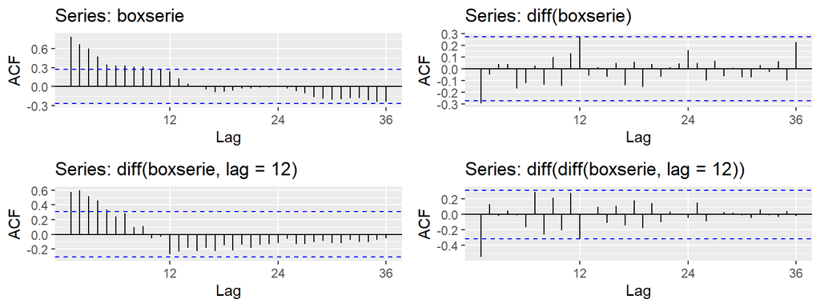

```r
# La serie temporal es mensual (frecuencia 12), entonces lag = 12
# De retardos he puesto 36 (múltiplo de 12)

a <- ggAcf(boxserie, lag = 36)
b <- ggAcf(diff(boxserie), lag = 36)
c <- ggAcf(diff(boxserie, lag = 12),lag = 36)
d <- ggAcf(diff(diff(boxserie, lag = 12)), lag = 36)

(FAC<- plot_grid(a, b, c, d, ncol=2, nrow=2))
```

El primer panel muestra que la serie al cabo de 12 retardos los coeficientes de autocorrelación ya son nulos.

Por otro lado, las funciones *ndiffs* y *nsdiffs* indican que son necesarias 1 diferenciación regular y 1 diferenciación estacional.

```r
# Identifica el número de diferenciaciones regulares
ndiffs(boxserie)
```

```
## [1] 1
```

```r
  # La función aplica el contraste de KPSS reiteradamente para identificar el número adecuado de diferenciaciones. Permite fijar el nivel de significatividad, el tipo de contraste y el tipo de tendencia determinista.
ndiffs(boxserie, alpha = 0.05, test = "kpss", type = "trend")
```

```
## [1] 1
```

```r
# Identifica el número de diferenciaciones estacionales
nsdiffs(boxserie)
```

```
## [1] 1
```

Por tanto, para obtener la estacionariedad y verificar la hipótesis de ergodicidad es necesario diferenciar en ambas partes: la regular y la estacional de la serie. Es decir, la serie que verifica todas las hipótesis es ($\Delta\Delta_{m}y_t$) o ($\Delta\Delta_{m}llamadas_t$).

Se grafica a continuación la serie original y la serie transformada:

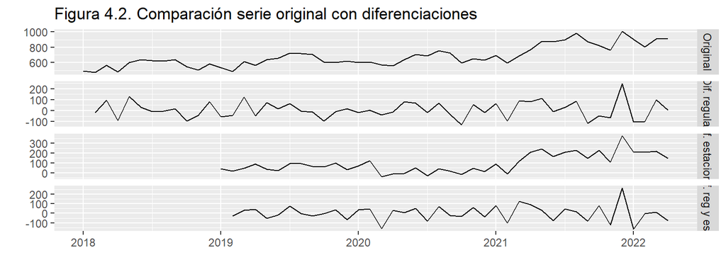

```r
series <- cbind("Original" = serie,
                "Dif. regular" = diff(serie),
                "Dif. estacional" = diff(serie, lag = 12),
                "Dif. reg y esta." = diff(diff(serie, lag = 12)))

autoplot(series, facets = TRUE,
         xlab = "",
         ylab = "",
         main = "Figura 4.2. Comparación serie original con diferenciaciones")
```

#### **Contraste KPSS**

Se realiza un contraste de raíces unitarias; la prueba de Kwiatkowski-Phillips-Schmidt-Shin. Dicha prueba usa un contraste de Multiplicadores de Lagrange para contrastar la estacionariedad de una serie en torno a una tendencia determinista, frente a la hipótesis alternativa de existencia de una raíz unitaria. Es decir la hipótesis nula es que la serie no tiene tendencia estocástica (la ausencia de raíz unitaria no es una prueba de estacionariedad, sino de estacionariedad en torno a una tendencia determinista).

**(Hay que tener en cuenta que este tipo de contraste de raíces unitarias pueden llegar a tener resultados muy paradójicos y pueden resultar poco útiles en la práctica)**

```r
# Con tendencia determinista
summary(ur.kpss(boxserie, type = "tau", lags = "short"))
```

```
##
## #######################
## # KPSS Unit Root Test #
## #######################
##
## Test is of type: tau with 3 lags.
##
## Value of test-statistic is: 0.1219
##
## Critical value for a significance level of:
##                 10pct  5pct 2.5pct  1pct
## critical values 0.119 0.146  0.176 0.216
```

```r
# Sin tendencia determinista
summary(ur.kpss(boxserie, type = "mu", lags = "short"))
```

```
##
## #######################
## # KPSS Unit Root Test #
## #######################
##
## Test is of type: mu with 3 lags.
##
## Value of test-statistic is: 1.0931
##
## Critical value for a significance level of:
##                 10pct  5pct 2.5pct  1pct
## critical values 0.347 0.463  0.574 0.739
```

Para un nivel de confianza del 5%, si se asume la presencia de tendencia determinista el estadístico de contraste es ligeramente menor que el valor crítico; sin embargo sin asumir tendencia determinista hay tendencia estocástica (el estadístico de contraste es mayor que el valor crítico).

```r
# Sin tendencia determinista
summary(ur.kpss((diff(boxserie, lag = 12)), type = "mu", lags = "short"))
```

```
##
## #######################
## # KPSS Unit Root Test #
## #######################
##
## Test is of type: mu with 3 lags.
##
## Value of test-statistic is: 0.6272
##
## Critical value for a significance level of:
##                 10pct  5pct 2.5pct  1pct
## critical values 0.347 0.463  0.574 0.739
```

En este caso los resultados de la prueba KPSS no son consistentes y resultan paradójicos. Por lo tanto, estos resultados no serán considerados.

Se grafica a continuación la serie original y la serie con las diferenciaciones:

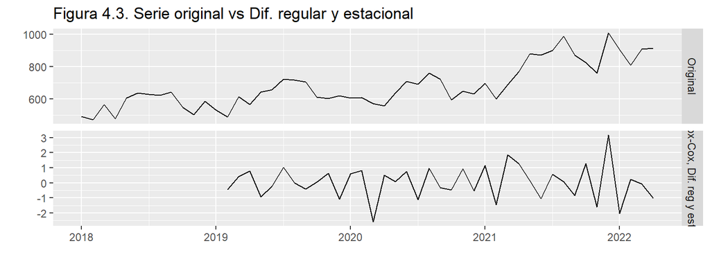

```r
series <- cbind("Original" = serie,
                "Box-Cox, Dif. reg y esta." = diff(diff(boxserie, lag = 12)))

autoplot(series, facets = TRUE,
         xlab = "",
         ylab = "",
         main = "Figura 4.3. Serie original vs Dif. regular y estacional")
```

## 4.2. Identificación

Como la serie hay que aplicarle una diferenciación regular y una diferenciación estacional para que sea estacionaria, se opta por considerar *d = 1* y *D = 1* de primeras.

### **Identificación con la FAC y la FACP**

La FAC y la función de autocorrelación parcial (FACP) de la serie:

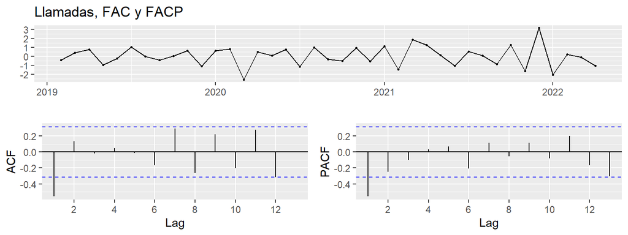

```r
ggtsdisplay(diff(diff(boxserie, lag = 12)),
            main = "Llamadas, FAC y FACP")
```

Respecto a identificar los valores de *p*, *q*, *P* y *Q*, se podría tratar de obtenerlos mediante una interpretación visual de la función de autocorrelación (FAC) y la función de autocorrelación parcial (FACP) de la serie. Sin embargo, debido a la dificultad de interpretar correctamente mediante esta metodología, se ha decidido utilizar directamente la función *auto.arima*.

### **Identificación automática**

Se va a utilizar la función **auto.arima()** para localizar el mejor modelo. Se va a poner de partida que *d = 1* y *D = 1* debido a que anteriormente se ha visto que es necesario para que sea estacionaria y ergódica.

```r
auto.arima(boxserie, d = 1, D = 1,
           stepwise = FALSE,
           approximation = FALSE,
           trace = TRUE)
```

```
##
##  ARIMA(0,1,0)(0,1,0)[12]                    : 120.2661
##  ARIMA(0,1,0)(0,1,1)[12]                    : 113.4501
##  ARIMA(0,1,0)(1,1,0)[12]                    : 116.6412
##  ARIMA(0,1,0)(1,1,1)[12]                    : Inf
##  ARIMA(0,1,1)(0,1,0)[12]                    : 106.7098
##  ARIMA(0,1,1)(0,1,1)[12]                    : 99.7909
##  ARIMA(0,1,1)(1,1,0)[12]                    : 101.536
##  ARIMA(0,1,1)(1,1,1)[12]                    : 102.2816
##  ARIMA(0,1,2)(0,1,0)[12]                    : 107.4949
##  ARIMA(0,1,2)(0,1,1)[12]                    : 100.5749
##  ARIMA(0,1,2)(1,1,0)[12]                    : 101.5906
##  ARIMA(0,1,2)(1,1,1)[12]                    : 103.1144
##  ARIMA(0,1,3)(0,1,0)[12]                    : 109.9843
##  ARIMA(0,1,3)(0,1,1)[12]                    : 102.9644
##  ARIMA(0,1,3)(1,1,0)[12]                    : 104.1872
##  ARIMA(0,1,3)(1,1,1)[12]                    : 105.6803
##  ARIMA(0,1,4)(0,1,0)[12]                    : 112.6246
##  ARIMA(0,1,4)(0,1,1)[12]                    : 105.7437
##  ARIMA(0,1,4)(1,1,0)[12]                    : 106.9694
##  ARIMA(0,1,5)(0,1,0)[12]                    : 115.3623
##  ARIMA(1,1,0)(0,1,0)[12]                    : 108.1847
##  ARIMA(1,1,0)(0,1,1)[12]                    : 102.7372
##  ARIMA(1,1,0)(1,1,0)[12]                    : 103.9086
##  ARIMA(1,1,0)(1,1,1)[12]                    : 105.2235
##  ARIMA(1,1,1)(0,1,0)[12]                    : 107.6288
##  ARIMA(1,1,1)(0,1,1)[12]                    : 101.0677
##  ARIMA(1,1,1)(1,1,0)[12]                    : 102.1604
##  ARIMA(1,1,1)(1,1,1)[12]                    : 103.6649
##  ARIMA(1,1,2)(0,1,0)[12]                    : 109.9843
##  ARIMA(1,1,2)(0,1,1)[12]                    : 102.3856
##  ARIMA(1,1,2)(1,1,0)[12]                    : 104.1913
##  ARIMA(1,1,2)(1,1,1)[12]                    : Inf
##  ARIMA(1,1,3)(0,1,0)[12]                    : Inf
##  ARIMA(1,1,3)(0,1,1)[12]                    : 105.1863
##  ARIMA(1,1,3)(1,1,0)[12]                    : Inf
##  ARIMA(1,1,4)(0,1,0)[12]                    : Inf
##  ARIMA(2,1,0)(0,1,0)[12]                    : 107.8636
##  ARIMA(2,1,0)(0,1,1)[12]                    : 101.2601
##  ARIMA(2,1,0)(1,1,0)[12]                    : 102.0508
```

[output cut: 11 more lines]

```
##  ARIMA(3,1,0)(1,1,0)[12]                    : 104.1444
##  ARIMA(3,1,0)(1,1,1)[12]                    : 105.6292
##  ARIMA(3,1,1)(0,1,0)[12]                    : 112.6088
##  ARIMA(3,1,1)(0,1,1)[12]                    : 105.6463
##  ARIMA(3,1,1)(1,1,0)[12]                    : 106.9442
##  ARIMA(3,1,2)(0,1,0)[12]                    : Inf
##  ARIMA(4,1,0)(0,1,0)[12]                    : 112.6044
##  ARIMA(4,1,0)(0,1,1)[12]                    : 105.5855
##  ARIMA(4,1,0)(1,1,0)[12]                    : 106.9313
##  ARIMA(4,1,1)(0,1,0)[12]                    : 115.4153
##  ARIMA(5,1,0)(0,1,0)[12]                    : 114.9327
##
##
##
##  Best model: ARIMA(0,1,1)(0,1,1)[12]
```

```
## Series: boxserie
## ARIMA(0,1,1)(0,1,1)[12]
##
## Coefficients:
##           ma1     sma1
##       -0.6062  -0.7109
## s.e.   0.1029   0.3651
##
## sigma^2 = 0.5445:  log likelihood = -46.55
## AIC=99.11   AICc=99.79   BIC=104.1
```

```r
  # Para hacer una búsqueda exhaustiva entre todos los posibles modelos stepwise = FALSE
  # Cálculo del AICc exacto (sin aproximar), approximation = FALSE
  # Para ver todos los modelos analizados y su correspondiente valor AICc, trace = TRUE
```

La función *auto.arima* propone una combinación de procesos regulares y estacionales, concretamente el proceso:
$$ARIMA_{12}(0,1,1)(0,1,1)$$
.

Antes de seguir con esta propuesta de *auto.arima*, se va a mirar la gráfica de los residuos del modelo propuesto, ya que anteriormente se identificaron valores extremos (intervención). Entonces se va a volver a solicitar la autoidentificación teniendo en cuenta variables ficticias asociadas a estos valores extremos.

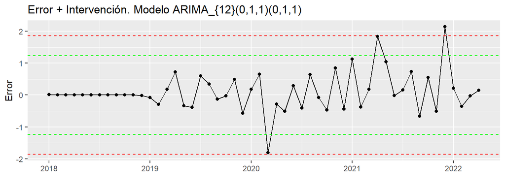

```r
arima011011 <- Arima(boxserie,
                  order = c(0, 1, 1),
                  seasonal = c(0, 1, 1))

error <- residuals(arima011011)
sderror <- sd(error)

autoplot(error, series = "error",
         colour = "black",
         xlab = "",
         ylab = "Error",
         main = "Error + Intervención. Modelo ARIMA_{12}(0,1,1)(0,1,1)") +
  geom_hline(yintercept = c(-3, -2, 2, 3)*sderror,
             colour = c("red", "green", "green", "red"),
             lty = 2) +
  geom_point() +
  scale_x_continuous(breaks = seq(2018, 2023, 1))
```

```r
time(error)[abs(error) > 3*sderror]
```

```
## [1] 2021.917
```

```r
time(error)[abs(error) > 2.9*sderror]
```

```
## [1] 2020.167 2021.250 2021.917
```

Se identifica un valor extremo que supera las tres desviaciontes típicas; diciembre de 2021 y otros dos posibles valores extremos que superan las 2.9 desv. típicas: Marzo de 2020 y Abril de 2021.

```r
library(seasonal)

d0320 <- 1*(cycle(error) == 3 & trunc(time(error)) == 2020) # Marzo de 2020
d0421 <- 1*(cycle(error) == 4 & trunc(time(error)) == 2021) # Abril de 2021
d1221 <- 1*(cycle(error) == 12 & trunc(time(error)) == 2021) # Diciembre de 2021

auto.arima(boxserie, d = 1, D = 1,
           stepwise = FALSE,
           approximation = FALSE,
           trace = TRUE,
           xreg = cbind(d0320, d0421, d1221))
```

```
##
##  Regression with ARIMA(0,1,0)(0,1,0)[12] errors : 105.2859
##  Regression with ARIMA(0,1,0)(0,1,1)[12] errors : 103.386
##  Regression with ARIMA(0,1,0)(1,1,0)[12] errors : 103.8259
##  Regression with ARIMA(0,1,0)(1,1,1)[12] errors : 106.192
##  Regression with ARIMA(0,1,1)(0,1,0)[12] errors : 96.76189
##  Regression with ARIMA(0,1,1)(0,1,1)[12] errors : 93.37058
##  Regression with ARIMA(0,1,1)(1,1,0)[12] errors : 93.97243
##  Regression with ARIMA(0,1,1)(1,1,1)[12] errors : 96.32952
##  Regression with ARIMA(0,1,2)(0,1,0)[12] errors : 98.23583
##  Regression with ARIMA(0,1,2)(0,1,1)[12] errors : 94.56594
##  Regression with ARIMA(0,1,2)(1,1,0)[12] errors : 95.34467
##  Regression with ARIMA(0,1,2)(1,1,1)[12] errors : 97.7029
##  Regression with ARIMA(0,1,3)(0,1,0)[12] errors : 100.9273
##  Regression with ARIMA(0,1,3)(0,1,1)[12] errors : 97.23646
##  Regression with ARIMA(0,1,3)(1,1,0)[12] errors : 98.1752
##  Regression with ARIMA(0,1,3)(1,1,1)[12] errors : 100.6091
##  Regression with ARIMA(0,1,4)(0,1,0)[12] errors : 104.1136
##  Regression with ARIMA(0,1,4)(0,1,1)[12] errors : Inf
##  Regression with ARIMA(0,1,4)(1,1,0)[12] errors : 101.4111
##  Regression with ARIMA(0,1,5)(0,1,0)[12] errors : Inf
##  Regression with ARIMA(1,1,0)(0,1,0)[12] errors : 98.36057
##  Regression with ARIMA(1,1,0)(0,1,1)[12] errors : 95.70613
##  Regression with ARIMA(1,1,0)(1,1,0)[12] errors : 96.14472
##  Regression with ARIMA(1,1,0)(1,1,1)[12] errors : 98.65218
##  Regression with ARIMA(1,1,1)(0,1,0)[12] errors : 98.82781
##  Regression with ARIMA(1,1,1)(0,1,1)[12] errors : 95.43099
##  Regression with ARIMA(1,1,1)(1,1,0)[12] errors : 96.06702
##  Regression with ARIMA(1,1,1)(1,1,1)[12] errors : 98.56934
##  Regression with ARIMA(1,1,2)(0,1,0)[12] errors : 100.9803
##  Regression with ARIMA(1,1,2)(0,1,1)[12] errors : 97.41831
##  Regression with ARIMA(1,1,2)(1,1,0)[12] errors : 98.30505
##  Regression with ARIMA(1,1,2)(1,1,1)[12] errors : 100.7873
##  Regression with ARIMA(1,1,3)(0,1,0)[12] errors : Inf
##  Regression with ARIMA(1,1,3)(0,1,1)[12] errors : Inf
##  Regression with ARIMA(1,1,3)(1,1,0)[12] errors : Inf
##  Regression with ARIMA(1,1,4)(0,1,0)[12] errors : 107.39
##  Regression with ARIMA(2,1,0)(0,1,0)[12] errors : 98.74289
##  Regression with ARIMA(2,1,0)(0,1,1)[12] errors : 94.2843
##  Regression with ARIMA(2,1,0)(1,1,0)[12] errors : 95.16686
```

[output cut: 11 more lines]

```
##  Regression with ARIMA(3,1,0)(1,1,0)[12] errors : 98.30852
##  Regression with ARIMA(3,1,0)(1,1,1)[12] errors : 100.763
##  Regression with ARIMA(3,1,1)(0,1,0)[12] errors : 104.2779
##  Regression with ARIMA(3,1,1)(0,1,1)[12] errors : 100.7623
##  Regression with ARIMA(3,1,1)(1,1,0)[12] errors : 101.6996
##  Regression with ARIMA(3,1,2)(0,1,0)[12] errors : 105.0688
##  Regression with ARIMA(4,1,0)(0,1,0)[12] errors : 103.8785
##  Regression with ARIMA(4,1,0)(0,1,1)[12] errors : 100.5307
##  Regression with ARIMA(4,1,0)(1,1,0)[12] errors : 101.6074
##  Regression with ARIMA(4,1,1)(0,1,0)[12] errors : 107.102
##  Regression with ARIMA(5,1,0)(0,1,0)[12] errors : 106.7723
##
##
##
##  Best model: Regression with ARIMA(0,1,1)(0,1,1)[12] errors
```

```
## Series: boxserie
## Regression with ARIMA(0,1,1)(0,1,1)[12] errors
##
## Coefficients:
##           ma1     sma1    d0320   d0421   d1221
##       -0.5563  -0.5505  -0.9431  0.9787  1.8762
## s.e.   0.1108   0.2646   0.5007  0.5173  0.5852
##
## sigma^2 = 0.4495:  log likelihood = -39.37
## AIC=90.75   AICc=93.37   BIC=100.73
```

Teniendo en cuenta los valores extremos detectados como variables de intervención, *auto.arima* sigue proponiendo el modelo
$$ARIMA_{12}(0,1,1)(0,1,1)$$
.

Se va a estimar el modelo identificado incluyendo las variables de intervención para volver a analizar si quedan valores atípicos.

```r
arima011011 <- Arima(boxserie,
                  order = c(0, 1, 1),
                  seasonal = list(order = c(0, 1, 1), period = 12),
           xreg = cbind(d0320, d0421, d1221))

arima011011
```

```
## Series: boxserie
## Regression with ARIMA(0,1,1)(0,1,1)[12] errors
##
## Coefficients:
##           ma1     sma1    d0320   d0421   d1221
##       -0.5563  -0.5505  -0.9431  0.9787  1.8762
## s.e.   0.1108   0.2646   0.5007  0.5173  0.5852
##
## sigma^2 = 0.4495:  log likelihood = -39.37
## AIC=90.75   AICc=93.37   BIC=100.73
```

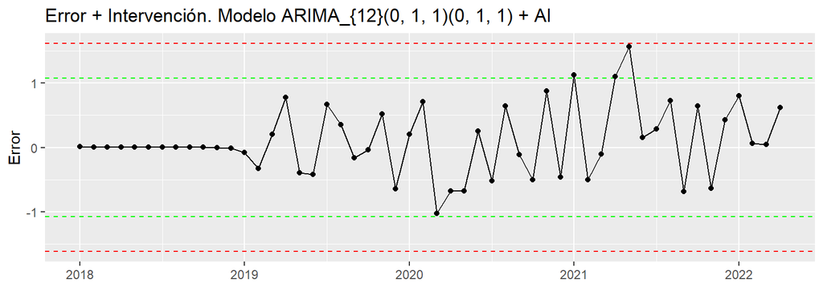

```r
error <- residuals(arima011011)
sderror <- sd(error)

autoplot(error, series = "error",
         colour = "black",
         xlab = "",
         ylab = "Error",
         main = "Error + Intervención. Modelo ARIMA_{12}(0, 1, 1)(0, 1, 1) + AI") +
  geom_hline(yintercept = c(-3, -2, 2, 3)*sderror,
             colour = c("red", "green", "green", "red"),
             lty = 2) +
  geom_point() +
  scale_x_continuous(breaks = seq(2018, 2023, 1))
```

```r
time(error)[abs(error) > 3*sderror]
```

```
## numeric(0)
```

```r
time(error)[abs(error) > 2.9*sderror]
```

```
## [1] 2021.333
```

```r
time(error)[abs(error) > 2.5*sderror]
```

```
## [1] 2021.333
```

```r
d0521 <- 1*(cycle(error) == 5 & trunc(time(error)) == 2021) # Mayo de 2021

auto.arima(boxserie, d = 1, D = 1,
           stepwise = FALSE,
           approximation = FALSE,
           trace = TRUE,
           xreg = cbind(d0320, d0421, d0521, d1221))
```

```
##
##  Regression with ARIMA(0,1,0)(0,1,0)[12] errors : 102.7755
##  Regression with ARIMA(0,1,0)(0,1,1)[12] errors : 102.4194
##  Regression with ARIMA(0,1,0)(1,1,0)[12] errors : 102.6953
##  Regression with ARIMA(0,1,0)(1,1,1)[12] errors : 105.3983
##  Regression with ARIMA(0,1,1)(0,1,0)[12] errors : 93.91205
##  Regression with ARIMA(0,1,1)(0,1,1)[12] errors : 92.15711
##  Regression with ARIMA(0,1,1)(1,1,0)[12] errors : 92.30055
##  Regression with ARIMA(0,1,1)(1,1,1)[12] errors : 95.28379
##  Regression with ARIMA(0,1,2)(0,1,0)[12] errors : 94.10226
##  Regression with ARIMA(0,1,2)(0,1,1)[12] errors : 91.98528
##  Regression with ARIMA(0,1,2)(1,1,0)[12] errors : 91.81239
##  Regression with ARIMA(0,1,2)(1,1,1)[12] errors : 95.14396
##  Regression with ARIMA(0,1,3)(0,1,0)[12] errors : 96.54053
##  Regression with ARIMA(0,1,3)(0,1,1)[12] errors : 95.03422
##  Regression with ARIMA(0,1,3)(1,1,0)[12] errors : 95.01994
##  Regression with ARIMA(0,1,3)(1,1,1)[12] errors : 98.54655
##  Regression with ARIMA(0,1,4)(0,1,0)[12] errors : 99.84026
##  Regression with ARIMA(0,1,4)(0,1,1)[12] errors : 98.66935
##  Regression with ARIMA(0,1,4)(1,1,0)[12] errors : 98.64615
##  Regression with ARIMA(0,1,5)(0,1,0)[12] errors : Inf
##  Regression with ARIMA(1,1,0)(0,1,0)[12] errors : 95.72823
##  Regression with ARIMA(1,1,0)(0,1,1)[12] errors : 93.2174
##  Regression with ARIMA(1,1,0)(1,1,0)[12] errors : 93.18042
##  Regression with ARIMA(1,1,0)(1,1,1)[12] errors : 96.21225
##  Regression with ARIMA(1,1,1)(0,1,0)[12] errors : 95.75671
##  Regression with ARIMA(1,1,1)(0,1,1)[12] errors : 93.49161
##  Regression with ARIMA(1,1,1)(1,1,0)[12] errors : 93.4101
##  Regression with ARIMA(1,1,1)(1,1,1)[12] errors : 96.68974
##  Regression with ARIMA(1,1,2)(0,1,0)[12] errors : 96.75373
##  Regression with ARIMA(1,1,2)(0,1,1)[12] errors : 95.06338
##  Regression with ARIMA(1,1,2)(1,1,0)[12] errors : 95.04254
##  Regression with ARIMA(1,1,2)(1,1,1)[12] errors : 98.56629
##  Regression with ARIMA(1,1,3)(0,1,0)[12] errors : Inf
##  Regression with ARIMA(1,1,3)(0,1,1)[12] errors : Inf
##  Regression with ARIMA(1,1,3)(1,1,0)[12] errors : Inf
##  Regression with ARIMA(1,1,4)(0,1,0)[12] errors : Inf
##  Regression with ARIMA(2,1,0)(0,1,0)[12] errors : 94.51499
##  Regression with ARIMA(2,1,0)(0,1,1)[12] errors : 92.29002
##  Regression with ARIMA(2,1,0)(1,1,0)[12] errors : 92.11523
```

[output cut: 11 more lines]

```
##  Regression with ARIMA(3,1,0)(1,1,0)[12] errors : 95.52191
##  Regression with ARIMA(3,1,0)(1,1,1)[12] errors : 99.09081
##  Regression with ARIMA(3,1,1)(0,1,0)[12] errors : 100.6024
##  Regression with ARIMA(3,1,1)(0,1,1)[12] errors : 99.27922
##  Regression with ARIMA(3,1,1)(1,1,0)[12] errors : 99.1609
##  Regression with ARIMA(3,1,2)(0,1,0)[12] errors : 103.3724
##  Regression with ARIMA(4,1,0)(0,1,0)[12] errors : 99.03269
##  Regression with ARIMA(4,1,0)(0,1,1)[12] errors : 98.63442
##  Regression with ARIMA(4,1,0)(1,1,0)[12] errors : 98.65171
##  Regression with ARIMA(4,1,1)(0,1,0)[12] errors : 102.4707
##  Regression with ARIMA(5,1,0)(0,1,0)[12] errors : 102.2189
##
##
##
##  Best model: Regression with ARIMA(0,1,2)(1,1,0)[12] errors
```

```
## Series: boxserie
## Regression with ARIMA(0,1,2)(1,1,0)[12] errors
##
## Coefficients:
##           ma1     ma2     sar1    d0320   d0421   d0521   d1221
##       -0.8039  0.3526  -0.4225  -0.7517  0.8591  1.3663  1.8654
## s.e.   0.1742  0.1661   0.1589   0.4256  0.5030  0.5028  0.5042
##
## sigma^2 = 0.4077:  log likelihood = -35.51
## AIC=87.01   AICc=91.81   BIC=100.32
```

```r
arima012110 <- Arima(boxserie,
                  order = c(0, 1, 2),
                  seasonal = list(order = c(1, 1, 0), period = 12),
           xreg = cbind(d0320, d0421, d0521, d1221))

arima012110
```

```
## Series: boxserie
## Regression with ARIMA(0,1,2)(1,1,0)[12] errors
##
## Coefficients:
##           ma1     ma2     sar1    d0320   d0421   d0521   d1221
##       -0.8039  0.3526  -0.4225  -0.7517  0.8591  1.3663  1.8654
## s.e.   0.1742  0.1661   0.1589   0.4256  0.5030  0.5028  0.5042
##
## sigma^2 = 0.4077:  log likelihood = -35.51
## AIC=87.01   AICc=91.81   BIC=100.32
```

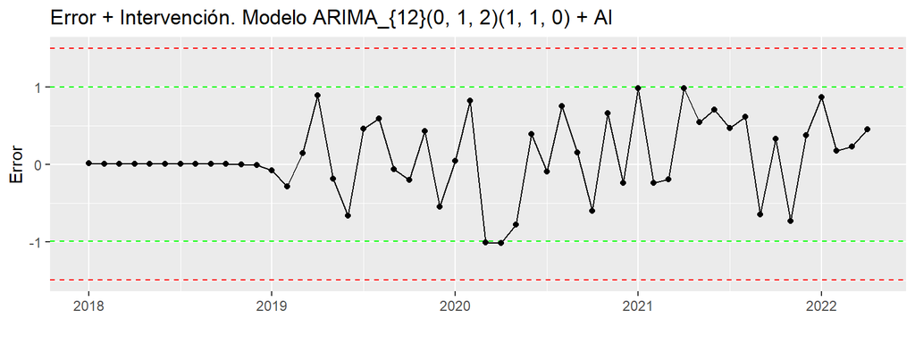

```r
error <- residuals(arima012110)
sderror <- sd(error)

autoplot(error, series = "error",
         colour = "black",
         xlab = "",
         ylab = "Error",
         main = "Error + Intervención. Modelo ARIMA_{12}(0, 1, 2)(1, 1, 0) + AI") +
  geom_hline(yintercept = c(-3, -2, 2, 3)*sderror,
             colour = c("red", "green", "green", "red"),
             lty = 2) +
  geom_point() +
  scale_x_continuous(breaks = seq(2018, 2023, 1))
```

```r
time(error)[abs(error) > 2.5*sderror]
```

```
## numeric(0)
```

```r
time(error)[abs(error) > 3*sderror]
```

```
## numeric(0)
```

```r
summary(seas(serie))
```

```
##
## Call:
## seas(x = serie)
##
## Coefficients:
##                    Estimate Std. Error z value Pr(>|z|)
## Weekday           -0.006477   0.001711  -3.785 0.000154 ***
## Easter[1]          0.094616   0.026558   3.563 0.000367 ***
## LS2020.Mar        -0.157609   0.041854  -3.766 0.000166 ***
## AO2021.Dec         0.180844   0.041888   4.317 1.58e-05 ***
## AR-Nonseasonal-01 -0.588841   0.102904  -5.722 1.05e-08 ***
## MA-Seasonal-12     0.999379   0.190246   5.253 1.50e-07 ***
## ---
## Signif. codes:  0 '***' 0.001 '**' 0.01 '*' 0.05 '.' 0.1 ' ' 1
##
## SEATS adj.  ARIMA: (1 1 0)(0 1 1)  Obs.: 52  Transform: log
## AICc: 413.2, BIC: 421.3  QS (no seasonality in final):    0
## Box-Ljung (no autocorr.): 42.08 * Shapiro (normality): 0.9697
## Messages generated by X-13:
## Notes:
## - The program cannot perform hypothesis tests for kurtosis on
##   less than 50 observations.
```

Teniendo en cuenta estos análisis se concluye que se utilizará:
$$ARIMA_{12}(0,1,1)(0,1,1)$$
,

## 4.3. Validación

### Variables significativas

Asumiendo que ya no hay más valores extremos, se va a mirar si todos los coeficientes del modelo son significativos aplicando la prueba de Wald.

```r
arima011011 <- Arima(boxserie,
                  order = c(0, 1, 1),
                  seasonal = c(0, 1, 1))

library(aod) # para la prueba de Wald

prueba.Wald <- max(nchar(names(coef(arima011011)))) + 2
for (i in 1:length(coef(arima011011))) {
  wt <- wald.test(b = coef(arima011011),
                  Sigma = vcov(arima011011),
                  Terms = i)
  cat("\nCoeficiente: ",
      format(names(coef(arima011011))[i],
             width = prueba.Wald),
      "valor de p: ",
      formatC(wt$result$chi2[3],
              digits = 3, format = "f"))
}
```

```
##
## Coeficiente:  ma1    valor de p:  0.000
## Coeficiente:  sma1   valor de p:  0.052
```

### Incorrelación, Homocedasticidad y Normalidad

Se ve si el residuo es ruido blanco:

**Incorrelación**

$$H_0: \rho_1 = ... = \rho_k =
0$$

**Homocedasticidad**

La hipótesis nula seria que las primeras *k* autocorrelaciones estimadas sobre el cuadrado del residuo son cero.

```r
error <- residuals(arima011011)

for (i in 2:7) { # Incorrelación
  inc <- Box.test(error, lag = i, type = "Ljung-Box")
  cat("\np-valor: ",
      formatC(inc$p.value,
              digits = 4, format = "f"))
}
```

```
##
## p-valor:  0.4625
## p-valor:  0.6136
## p-valor:  0.6622
## p-valor:  0.7900
## p-valor:  0.8629
## p-valor:  0.7367
```

```r
for (i in 2:6) { # Homocedasticidad
  homoc <- Box.test(error^2, lag = i, type = "Ljung-Box")
  cat("\np-valor: ",
      formatC(homoc$p.value,
              digits = 4, format = "f"))
}
```

```
##
## p-valor:  0.8788
## p-valor:  0.9451
## p-valor:  0.9834
## p-valor:  0.9954
## p-valor:  0.9951
```

```r
library(tseries) # libreria para el test de Jarque Bera

jarque.bera.test(error) # Normalidad
```

```
##
##  Jarque Bera Test
##
## data:  error
## X-squared = 22.635, df = 2, p-value = 1.216e-05
```

Las hipótesis de incorrelación y homocedasticidad se aceptan (incluso para otros valores de *k* razonables). Sin embargo, la hipótesis de normalidad se rechaza (p-valor significativo < 0.05); aunque esto no impide usar el modelo ARIMA para predecir.

### Calidad del ajuste (medidas de error)

```r
arima011011
```

```
## Series: boxserie
## ARIMA(0,1,1)(0,1,1)[12]
##
## Coefficients:
##           ma1     sma1
##       -0.6062  -0.7109
## s.e.   0.1029   0.3651
##
## sigma^2 = 0.5445:  log likelihood = -46.55
## AIC=99.11   AICc=99.79   BIC=104.1
```

```r
accuracy(arima011011)
```

```
##                     ME      RMSE       MAE       MPE     MAPE      MASE
## Training set 0.1030165 0.6224497 0.4023438 0.3579519 1.605606 0.2900288
##                    ACF1
## Training set -0.1650362
```

```r
round(accuracy(arima011011),2)
```

```
##               ME RMSE MAE  MPE MAPE MASE  ACF1
## Training set 0.1 0.62 0.4 0.36 1.61 0.29 -0.17
```

## 4.4. Predicción

```r
arima011011 <- Arima(serie,
                  order = c(0, 1, 1),
                  seasonal = list(order = c(0, 1, 1), period = 12))

serieARIMA.prediccion <- forecast(arima011011,
                          h = 8, # 8 meses
                          level = 95) # nivel de confianza al 95%
serieARIMA.prediccion
```

```
##          Point Forecast    Lo 95    Hi 95
## May 2022      1009.2217 895.6308 1122.813
## Jun 2022      1032.2316 909.4594 1155.004
## Jul 2022      1050.3966 919.0835 1181.710
## Aug 2022      1101.4463 962.1150 1240.778
## Sep 2022      1045.9246 899.0119 1192.837
## Oct 2022       961.8698 807.7483 1115.991
## Nov 2022       942.1618 781.1539 1103.170
## Dec 2022      1053.6941 886.0825 1221.306
```

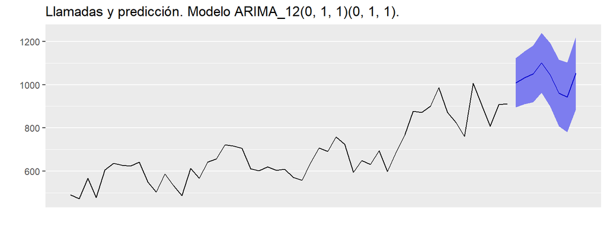

```r
autoplot(serieARIMA.prediccion,
         xlab = "",
         ylab = "",
         main = "Llamadas y predicción. Modelo ARIMA_12(0, 1, 1)(0, 1, 1).") +
  scale_x_continuous(breaks = seq(1, 226, 10))
```

### Comparación entre modelos

```r
k <- 36  # Utilizaremos 36 meses en lugar de 24 para el entrenamiento
h <- 12  # Pronóstico de 12 meses (1 año)
TT <- length(boxserie)
s <- TT - k - h  # Periodo de ajuste

mapeArima <- matrix(NA, s + 1, h)
mapeArima2 <- matrix(NA, s + 1, h)
mapeArima3 <- matrix(NA, s + 1, h)

X <- cbind(d0320, d0421, d1221)
X2 <- cbind(d0320, d0421, d0521, d1221)

for (i in 0:s) {
  train.set <- subset(boxserie, start = i + 1, end = i + k)
  test.set <-  subset(boxserie, start = i + k + 1, end = i + k + h)

  # Opción 1. ARIMA_12(0, 1, 1)(0, 1, 1)

  fit <- try(Arima(train.set,
                   order = c(0, 1, 1),
                   seasonal = list(order = c(0, 1, 1), period = 12)),
             silent = TRUE)

  if (!is.element("try-error", class(fit))) {
    fcast <- forecast(fit, h = h)
    mapeArima[i + 1, ] <- 100 * abs(test.set - fcast$mean) / test.set
  }

  # Opción 2. ARIMA_12(0, 1, 1)(0, 1, 1) + AI
  X.train <- X[(i + 1):(i + k),]
  hay <- colSums(X.train)
  X.train <- X.train[, hay > 0]

  X.test <- X[(i + k + 1):(i + k + h),]
  X.test <- X.test[, hay > 0]

  fit <- try(Arima(train.set,
                   order = c(0, 1, 1),
                   seasonal = list(order = c(0, 1, 1), period = 12),
                   xreg = X.train), silent = TRUE)

  if (!is.element("try-error", class(fit))) {
    fcast <- forecast(fit, h = h, xreg = X.test)
    mapeArima2[i + 1, ] <- 100 * abs(test.set - fcast$mean) / test.set
  }

# Opción 3. ARIMA_12(0, 1, 2)(1, 1, 0) + AI
  X.train <- X2[(i + 1):(i + k),]
  hay <- colSums(X.train)
  X.train <- X.train[, hay > 0]

  X.test <- X2[(i + k + 1):(i + k + h),]
  X.test <- X.test[, hay > 0]

  fit <- try(Arima(train.set,
                   order = c(0, 1, 2),
                   seasonal = list(order = c(1, 1, 0), period = 12),
                   xreg = X.train), silent = TRUE)

  if (!is.element("try-error", class(fit))) {
    fcast <- forecast(fit, h = h, xreg = X.test)
    mapeArima3[i + 1, ] <- 100 * abs(test.set - fcast$mean) / test.set
  }

}

errorArima <- colMeans(mapeArima, na.rm = TRUE)
errorArima2 <- colMeans(mapeArima2, na.rm = TRUE)
errorArima3 <- colMeans(mapeArima3, na.rm = TRUE)

round(errorAlisado1, 2)
```

```
##  [1]  9.24  9.55 10.23 10.89 11.09 12.50 12.39 13.65 14.14 14.92 15.36 15.90
```

```r
round(errorArima, 2)
```

```
##  [1] 4.37 4.45 5.80 6.90 6.06 5.82 5.71 7.28 7.53 8.37 8.27 9.17
```

```r
round(errorArima2, 2)
```

```
##  [1]  4.97  4.88  5.88  7.48  6.59  6.72  6.30  7.86  7.97  8.72  8.71 10.25
```

```r
round(errorArima3, 2)
```

```
##  [1] 4.68 4.63 5.60 7.16 6.31 6.39 5.92 7.46 7.64 8.36 8.28 9.93
```

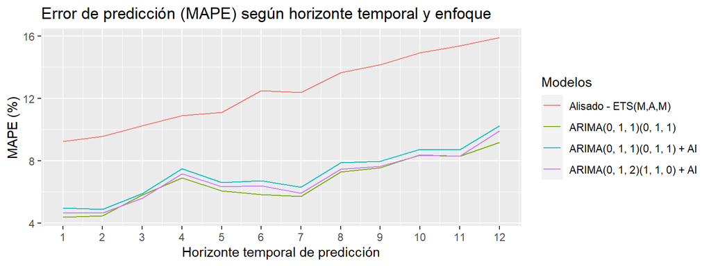

```r
ggplot() +
    geom_line(aes(x = 1:12, y = errorAlisado1, colour = "Alisado - ETS(M,A,M)")) +
    geom_line(aes(x = 1:12, y = errorArima, colour = "ARIMA(0, 1, 1)(0, 1, 1)"))  +
    geom_line(aes(x = 1:12, y = errorArima2, colour = "ARIMA(0, 1, 1)(0, 1, 1) + AI"))  +
    geom_line(aes(x = 1:12, y = errorArima3, colour = "ARIMA(0, 1, 2)(1, 1, 0) + AI"))  +
    ggtitle("Error de predicción (MAPE) según horizonte temporal y enfoque") +
    xlab("Horizonte temporal de predicción") +
    ylab("MAPE (%)") +
    scale_x_continuous(breaks= 1:12) + # error hasta 12 meses (1 año)
    guides(colour = guide_legend(title = "Modelos")) # título leyenda
```

```r
round(accuracy(serieETS), 2)
```

```
##                ME  RMSE   MAE   MPE MAPE MASE ACF1
## Training set 1.26 42.85 32.97 -0.01 4.78 0.32 0.02
```

```r
round(accuracy(arima011011), 2)
```

[output not shown]